# Explotació resultats simulació - BCN

IERMB

06 julio, 2021 - 14:22

Tots els resultats d’aquest document fan referència a la simulació amb dades per BCN. Les variables de rendes contemplen la transferència del IMV per les llars aplicables.

Referències simulació

| Variable | Valor |
| --- | --- |
| Territori | BCN |
| Escenari | U3 |
| n | 2514 |
| Iteracions | 1e+05 |
| Data simulació | 06/07/21 |
| Font dades atur | EPA 2020 |
| Referència temp. ERTOS | Desembre |
| Taxa d’atur projectada | 12.5 |
| Proporció atur amb prestació | 30.4 |
| Població afectada per ERTO | 28.3 |
| Assignació mesos a l’atur | probabilística |
| Base dades renda | EMCV |

### Taula 1.

Renda anual neta mitjana per llar, persona i unitat de consum (euros). BCN, 2016-2017, 2017-2018, 2018-2019 i estimacions 2020.

| Renda.anual.neta.mitjana | 16-17 | 17-18 | 18-19 | sim2020 |
| --- | --- | --- | --- | --- |
| per llar | 35605 | 36183 | 36331 | 33999.0 |
| per persona | 15140 | 15474 | 15594 | 14592.5 |
| per unitat de consum | 21926 | 22390 | 22567 | 21068.8 |

### Taula 2.

#### Decils

Variació relativa en la mitjana dels ingressos equivalents de la població segons decils de renda

| Decil | 2016-2017 | 2017-2018 | 2018-2019 | quantils_sim | quantils_pre |
| --- | --- | --- | --- | --- | --- |
| 1 | 5427.4 | 5238.2 | 4577.3 | 3915.2 | 4291.5 |
| 2 | 9298.6 | 9353.4 | 9637.7 | 8395.7 | 8512.3 |
| 3 | 12337.3 | 12672.7 | 12754.8 | 11517.2 | 12029.8 |
| 4 | 14498.0 | 14920.4 | 15560.6 | 14191.4 | 14188.8 |
| 5 | 17128.3 | 17610.0 | 18224.6 | 16775.8 | 17291.8 |
| 6 | 20393.4 | 20651.0 | 20443.9 | 19192.2 | 19224.4 |
| 7 | 24436.7 | 24444.0 | 23793.4 | 22554.3 | 22493.4 |
| 8 | 29243.1 | 29571.7 | 29001.5 | 27251.8 | 27446.5 |
| 9 | 34809.7 | 35626.8 | 35857.7 | 34197.1 | 34310.4 |
| 10 | 52390.8 | 54305.1 | 57423.8 | 52737.4 | 51062.7 |

| Decil | 2018-2019 | quantils_sim | quantils_pre | Nous_decils | Antics_decils |
| --- | --- | --- | --- | --- | --- |
| 1 | 4577.3 | 3915.2 | 4291.5 | -14.5 | -6.2 |
| 2 | 9637.7 | 8395.7 | 8512.3 | -12.9 | -11.7 |
| 3 | 12754.8 | 11517.2 | 12029.8 | -9.7 | -5.7 |
| 4 | 15560.6 | 14191.4 | 14188.8 | -8.8 | -8.8 |
| 5 | 18224.6 | 16775.8 | 17291.8 | -7.9 | -5.1 |
| 6 | 20443.9 | 19192.2 | 19224.4 | -6.1 | -6.0 |
| 7 | 23793.4 | 22554.3 | 22493.4 | -5.2 | -5.5 |
| 8 | 29001.5 | 27251.8 | 27446.5 | -6.0 | -5.4 |
| 9 | 35857.7 | 34197.1 | 34310.4 | -4.6 | -4.3 |
| 10 | 57423.8 | 52737.4 | 51062.7 | -8.2 | -11.1 |

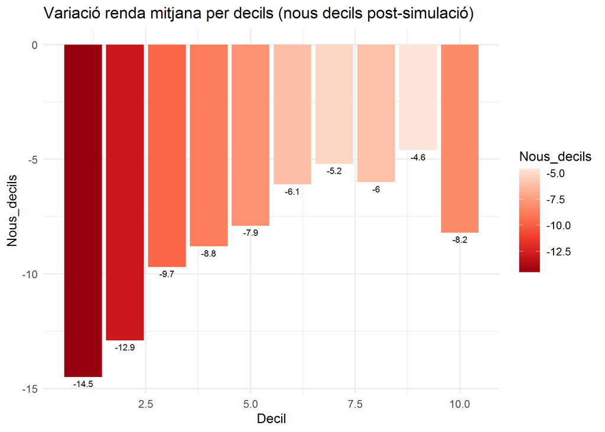

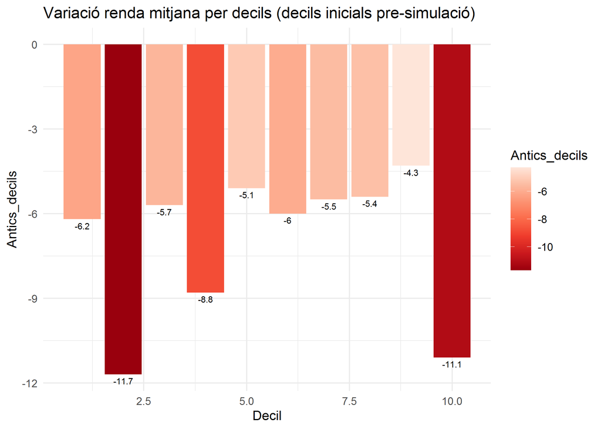

#### Quintils

Variació relativa en la mitjana dels ingressos equivalents de la població segons quintils

| Quintil | 2019 | quantils_sim | quantils_pre | Nous_quint | Antics_quint |
| --- | --- | --- | --- | --- | --- |
| 1 | 7041.5 | 6161.5 | 6397.0 | -12.5 | -9.2 |
| 2 | 14162.4 | 12834.9 | 13152.7 | -9.4 | -7.1 |
| 3 | 19333.2 | 17977.9 | 18271.5 | -7.0 | -5.5 |
| 4 | 26510.3 | 24902.8 | 24959.3 | -6.1 | -5.9 |
| 5 | 45896.8 | 43465.5 | 42669.5 | -5.3 | -7.0 |

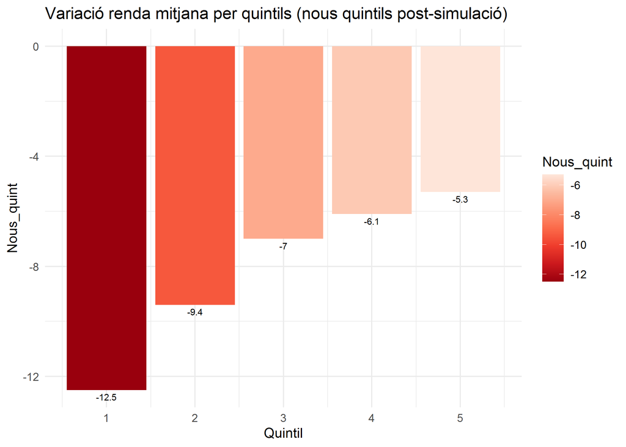

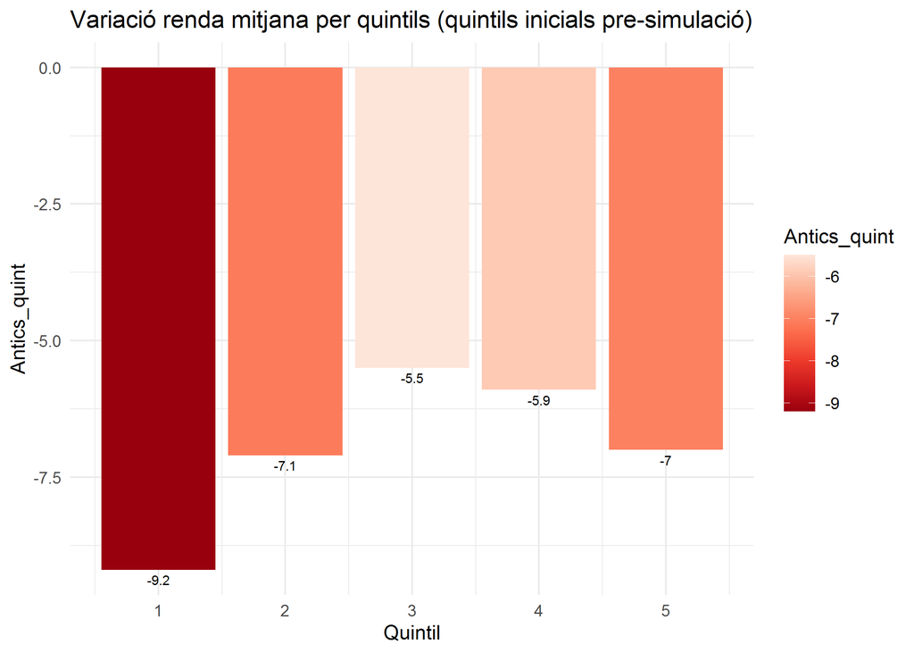

| quint_orig | roman | COV_quint_IMV | n |
| --- | --- | --- | --- |
| 1 | Canvi | 2 | 37171.9 |
| 1 | Igual | 1 | 286148.9 |
| 2 | Canvi | 1 | 34515.0 |
| 2 | Canvi | 3 | 45857.0 |
| 2 | Igual | 2 | 246735.6 |
| 3 | Canvi | 1 | 606.9 |
| 3 | Canvi | 2 | 22519.0 |
| 3 | Canvi | 4 | 46055.5 |
| 3 | Igual | 3 | 249424.1 |
| 4 | Canvi | 1 | 2176.0 |
| 4 | Canvi | 2 | 7442.8 |
| 4 | Canvi | 3 | 27962.1 |
| 4 | Canvi | 5 | 29934.3 |
| 4 | Igual | 4 | 256088.5 |
| 5 | Canvi | 1 | 1545.1 |
| 5 | Canvi | 2 | 5282.0 |
| 5 | Canvi | 3 | 1391.5 |
| 5 | Canvi | 4 | 21053.6 |
| 5 | Igual | 5 | 293192.3 |

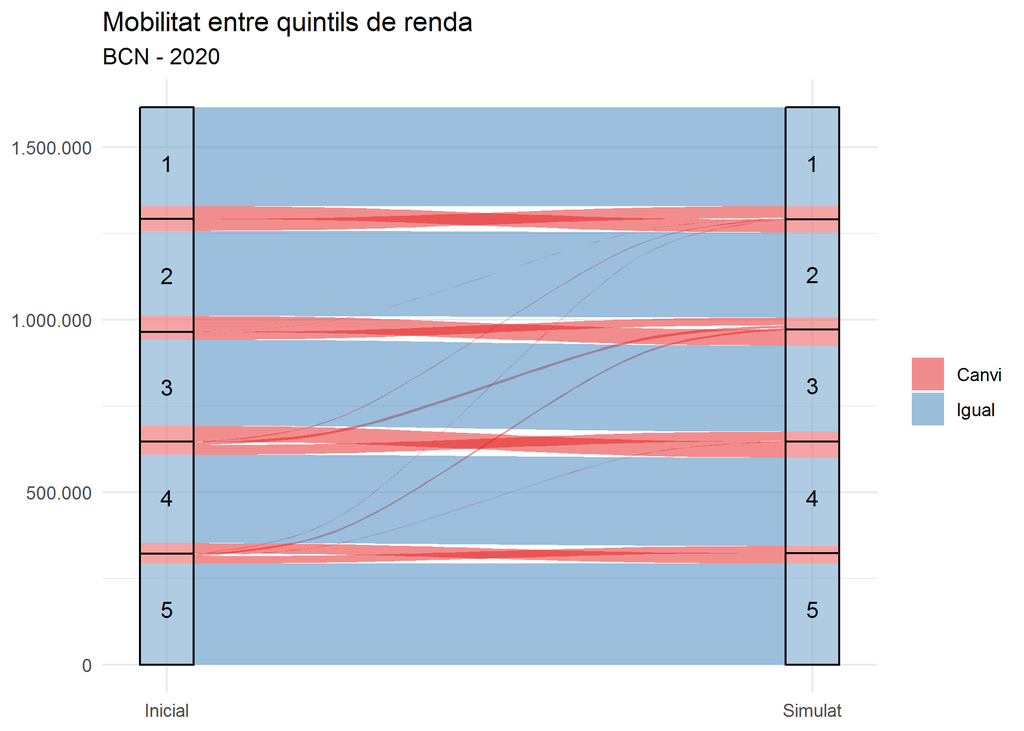

#### 3 Grups

Variació relativa en la mitjana dels ingressos equivalents de la població segons decils de renda agrupats

| Decil | 2019 | quantils_sim | quantils_pre | Nous_decils | Antics_decils |
| --- | --- | --- | --- | --- | --- |
| 1 | 8932.5 | 7942.3 | 8237.9 | -11.1 | -7.8 |
| 2 | 19440.9 | 18201.9 | 18258.4 | -6.4 | -6.1 |
| 3 | 40318.9 | 38060.6 | 37597.8 | -5.6 | -6.7 |

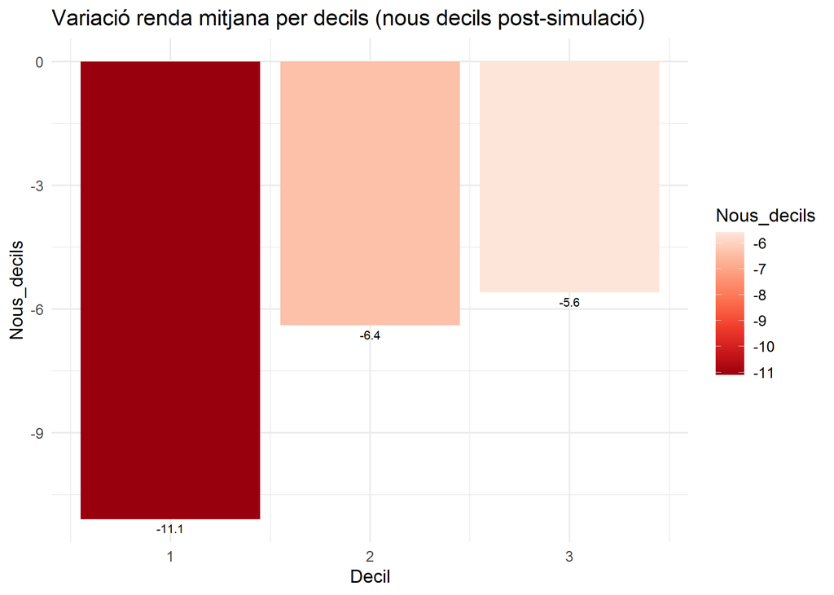

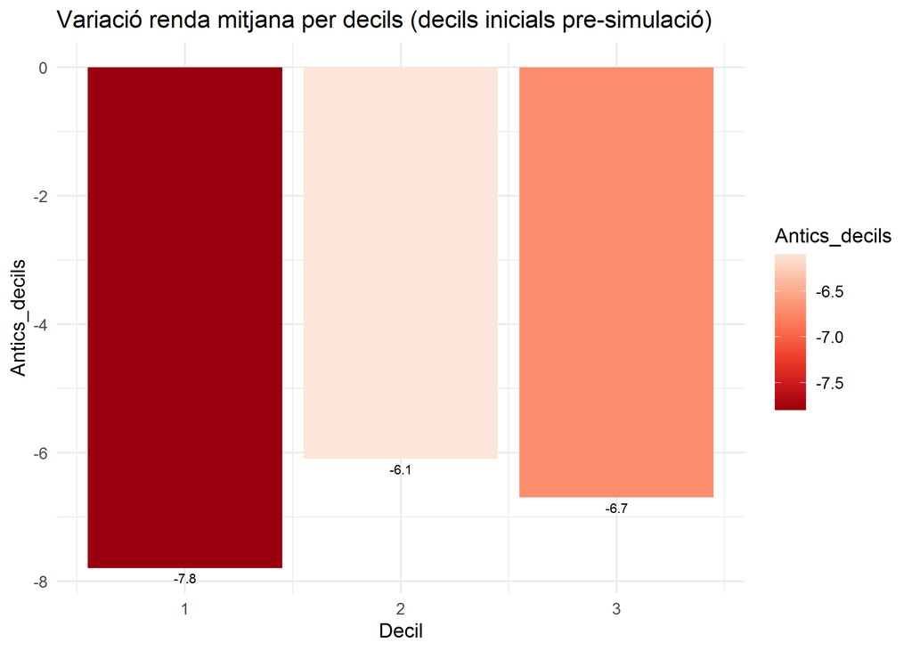

### Taula 3.1.

Índex de Gini

| Any | Valor | Sèrie |
| --- | --- | --- |
| 1985 | 39.8 | ECVHP |
| 1990 | 35.9 | ECVHP |
| 1995 | 33.9 | ECVHP |
| 2000 | 32.2 | ECVHP |
| 2006 | 30.8 | ECVHP |
| 2011 | 34.6 | ECVHP (base ECV 2004) |
| 16-17 | 33.4 | EMCV |
| 17-18 | 33.8 | EMCV |
| 18-19 | 34 | EMCV |
| sim2020 | 35.2 | Sim - EMCV |

### Taula 3.2.

Raons de desigualtat entre decils de renda

| P50/10 | P80/20 | S80/20 | P90/50 | P90/10 |
| --- | --- | --- | --- | --- |
| 2.9 | 2.9 | 7 | 2.1 | 6.3 |

| Raons | 2006 | 2011 | 16-17 | 17-18 | 18-19 | sim2020 |
| --- | --- | --- | --- | --- | --- | --- |
| P90/50 | 2.0 | 2.1 | 2.1 | 2.1 | 2.2 | 2.1 |
| P50/10 | 2.3 | 2.2 | 2.3 | 2.3 | 2.7 | 2.9 |

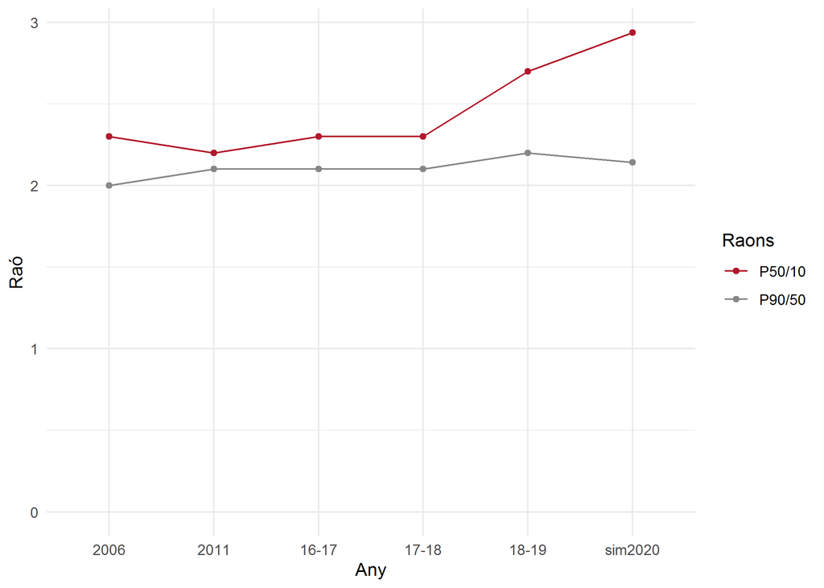

### Taula 4.1

Taxes de risc de pobresa segons intensitat

| indicador | 2011 | 16-17 | 17-18 | 18-19 | sim2020 |
| --- | --- | --- | --- | --- | --- |
| moderada (60%) | 24.1 | 21.3 | 21.6 | 21.0 | 20.9 |
| severa (40%) | 8.6 | 7.3 | 7.4 | 10.4 | 11.5 |
| extrema (30%) | 5.4 | 4.3 | 5.0 | 6.3 | 7.3 |

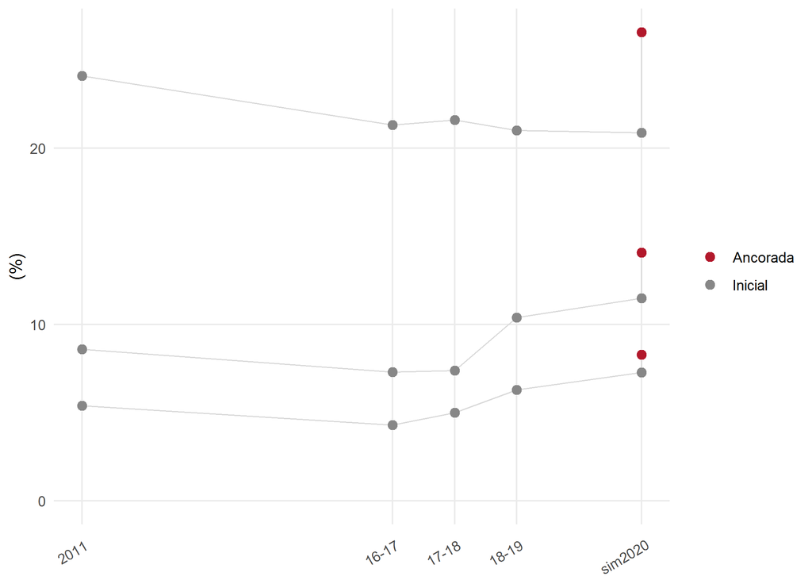

### Taula 4.2.

Intensitat de risc de pobresa

> % distance to poverty threshold: The indicator is calculated as the distance between the median equivalised total net income of persons below the at-risk-of-poverty threshold and the at-risk-of-poverty threshold itself, expressed as a percentage of the at-risk-of-poverty threshold. This threshold is set at 60 % of the national median equivalised disposable income of all people in a country and not for the EU as a whole.

| indicador | 2011 | 16-17 | 17-18 | 18-19 | sim2020 |
| --- | --- | --- | --- | --- | --- |
| Intensitat de risc de pobresa | 0.23 | 0.25 | 0.27 | 0.33 | 0.398 |
| Llindar | NA | NA | NA | NA | 10726.16 |
| Mediana IE pobres | NA | NA | NA | NA | 6457.004 |

### Taula 4.3

Pobresa ancorada (2018-2019) segons diferent intensitat. Llindar 2018-2019

| indicador | 2018-2019 | sim2020 |
| --- | --- | --- |
| Ancorada-Pobresa moderada (60% mediana) | 21.0 | 26.6 |
| Ancorada-Pobresa severa (40% mediana) | 10.4 | 14.1 |
| Ancorada-Pobresa extrema (30% mediana) | 6.3 | 8.3 |

### Taula 5.

Canvis a la pobresa estimada (60% mediana) segons característiques sociodemogràfiques

| var | categories | 17-18 | 18-19 | sim2020 | ANC2020 | ztest |
| --- | --- | --- | --- | --- | --- | --- |
| sexe | Dones | 20.8 | 20.4 | 20.4 | 25.5 | 4.6 |
| sexe | Homes | 22.4 | 21.7 | 21.5 | 27.7 | 5.0 |
| edat | 0-17 anys | 30.8 | 30.4 | 31.1 | 39.1 | 3.7 |
| edat | 18-34 anys | 26.9 | 20.7 | 21.6 | 28.2 | 4.1 |
| edat | 35-64 anys | 18.2 | 19.6 | 20.5 | 25.6 | 4.9 |
| edat | 65 i més anys | 16.5 | 17.0 | 13.1 | 17.6 | 0.3 |
| nacionalitat | Espanya | 13.9 | 10.9 | 9.5 | 14.0 | 4.3 |
| nacionalitat | Resta del món | 41.6 | 41.7 | 45.0 | 52.9 | 5.7 |
| llars | amb infants | 31.3 | 27.6 | 28.0 | 35.7 | 5.7 |
| llars | sense infants | 13.3 | 13.4 | 13.0 | 17.2 | 3.7 |
| llars | Unipersonal > 65 anys | 26.1 | 28.2 | 24.1 | 28.2 | 0.0 |
| llars | Unipersonal < 65 anys | 19.2 | 26.6 | 28.0 | 33.7 | 2.2 |
| csp | Directius i professionals | 7.7 | 7.5 | 8.4 | 11.6 | 4.3 |
| csp | Ocupacions intermèdies | 11.0 | 9.5 | 8.3 | 11.7 | 1.3 |
| csp | Petits empresaris i autònoms | 32.3 | 31.2 | 29.7 | 37.3 | 1.8 |
| csp | semiqualificats de serveis | 27.3 | 25.5 | 26.3 | 32.3 | 3.0 |
| csp | semiqualificats o de rutina | 34.3 | 31.4 | 31.8 | 40.0 | 3.8 |
| csp | ALLD/NTM | 30.4 | 28.6 | 25.9 | 34.1 | 1.8 |

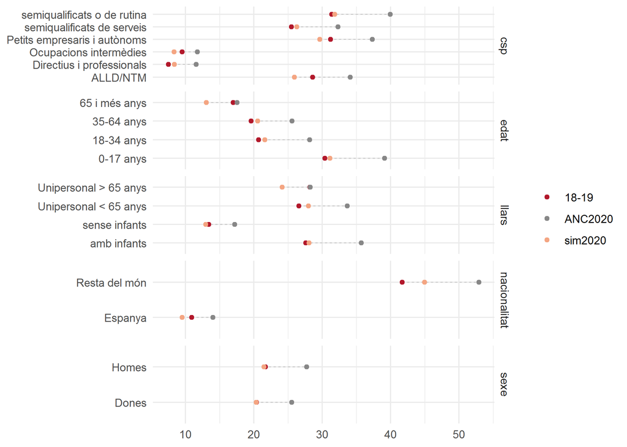

### Taula 6.

Proporció mitjana de la renda anual (neta) de les llars que es destina a les despeses fixes de l’habitatge (sense amortització), segons règim de tinença de l’habitatge.

| RTL | 2016-2017 | 2017-2018 | 2018-2019 | sim2020 |
| --- | --- | --- | --- | --- |
| Propietat totalment pagada | 10.6 | 10.3 | 9.6 | 10.1 |
| Propietat amb pagaments ajornats | 14.0 | 13.8 | 12.8 | 13.9 |
| En lloguer o relloguer | 39.0 | 39.4 | 40.5 | 45.7 |
| Un altre tipus de règim de tinença | 11.4 | 13.4 | 12.3 | 13.0 |
| Total | 21.6 | 22.5 | 23.1 | 25.7 |

### Taula 7.

Taxa de sobrecàrrega despeses habitatge (sense amortització) amb diferents llindars

| perc | RTL | 16-17 | 17-18 | 18-19 | sim2020 |
| --- | --- | --- | --- | --- | --- |
| >40% | pagada | 2.2 | 1.8 | 1.4 | 1.8 |
| >40% | pagaments | 3.0 | 4.2 | 2.1 | 2.6 |
| >40% | lloguer | 37.2 | 35.2 | 35.3 | 45.6 |
| >40% | altres | 2.4 | 2.5 | 3.7 | 3.7 |
| >60% | pagada | 1.5 | 1.1 | 0.7 | 0.9 |
| >60% | pagaments | 1.5 | 1.6 | 1.3 | 1.8 |
| >60% | lloguer | 14.3 | 16.7 | 18.3 | 24.7 |
| >60% | altres | 0.9 | 1.3 | 1.9 | 1.9 |

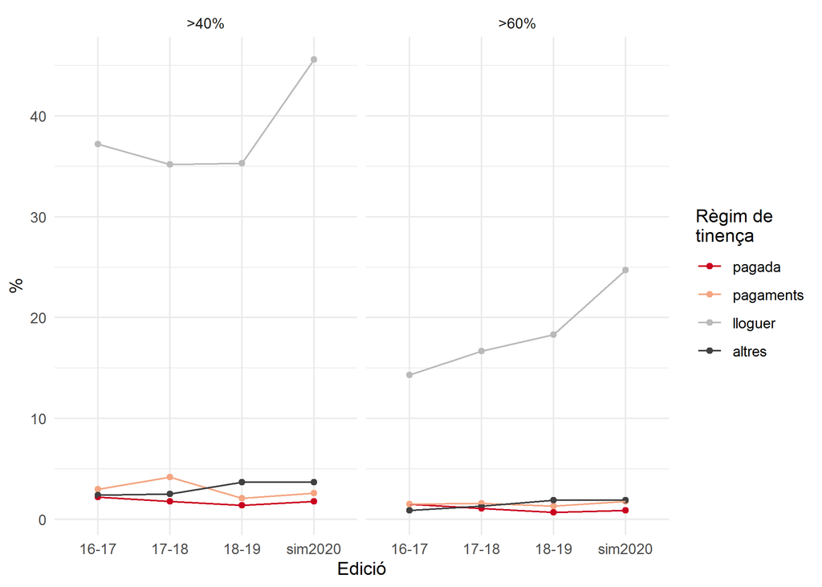

### Taula 8.

Taxa de risc de pobresa (60% mediana) abans i després del IMV

El llindar de referència fa servir les dades després de la injecció del IMV.

| TRP | abans | despres |
| --- | --- | --- |
| trp30 | 7.3 | 7.3 |
| trp40 | 11.5 | 11.5 |
| trp60 | 20.9 | 20.9 |